# R Notebook

# Statistics XII Homework Ch18_Textbook

## 18.17

### a

```r
#data processing
data1 <- read.csv("Xr18-17.csv",header = 1)
attendance <- data1$Attendance
yes.att <- data1$Yest.Att
I1 <- data1$I1
I2 <- data1$I2
I3 <- data1$I3
n <- length(attendance)
#
wk_u <- I1 == 1
wk_att <- attendance[wk_u]
wk_yes.att <- yes.att[wk_u]
sun_u <- I2 == 1
sun_att <- attendance[sun_u]
sun_yes.att <- yes.att[sun_u]
rain_u <- I3 == 1
rain_att <- attendance[rain_u]
rain_yes.att <- yes.att[rain_u]
#
wd_u <- I1 < 1
wd_att <- attendance[wd_u]
wd_yes.att <- yes.att[wd_u]
other_u <- (I2 < 1 & I3 < 1)
other_att <- attendance[other_u]
other_yes.att <- yes.att[other_u]
#scatter diagram_1
plot(wk_yes.att, wk_att, col = "green", main = "Attendance against The Previous Day's(weekend or not)", xlab = "previous day's att", ylab = "attendance", xlim=range(yes.att), ylim=range(attendance))
points(wd_yes.att, wd_att, col= "red")
```

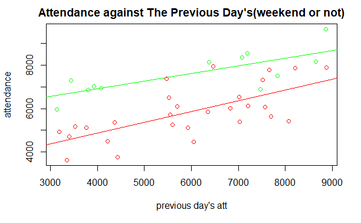

```r
abline(lm(wk_att ~ wk_yes.att), col = "green")
abline(lm(wd_att ~ wd_yes.att), col= "red")
```

```r
#scatter diagram_2
plot(sun_yes.att, sun_att, col = "green", main = "Attendance against The Previous Day's(weather.diff)", xlab = "previous day's att", ylab = "attendance", xlim=range(yes.att), ylim=range(attendance))
points(rain_yes.att, rain_att, col= "red")
```

```r
points(other_yes.att, other_att, col= "blue")
abline(lm(sun_att ~ sun_yes.att), col = "green")
```

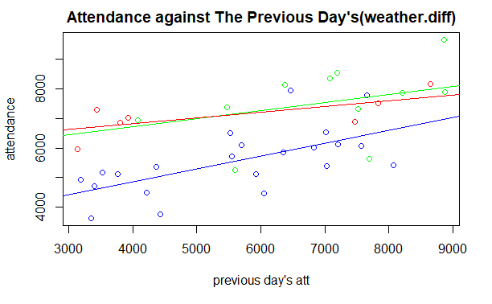

```r
abline(lm(rain_att ~ rain_yes.att), col= "red")
abline(lm(other_att ~ other_yes.att), col= "blue")
```

```
Propose a statistical model:
```

$$y\ =\ \beta_0\ +\ \beta_1x\ +\ \beta_2I_1\ +\ \beta_3I_2\ +\ \beta_4I_3\ +\ \varepsilon$$

y = the attendance

x = the previous day’s attendance

$I_1$ = day of the week (weekend = 1, else = 0)

$I_2$ = weather forecast (sunny is predicted = 1, else = 0)

$I_3$ = weather forecast (rain is predicted = 1, else = 0)

$\varepsilon$ = error variable

```r
attendance <- data1$Attendance
yes.att <- data1$Yest.Att
I1 <- data1$I1
I2 <- data1$I2
I3 <- data1$I3
n <- length(attendance)
Data.att <- cbind(yes.att, I1, I2, I3)
linearModelVar <- lm(attendance ~ Data.att)
cat("# # # # The regression model # # # ","\n")
```

```
# # # # The regression model # # #
```

```r
print(summary(linearModelVar))
```

```
Call:
lm(formula = attendance ~ Data.att)

Residuals:
     Min       1Q   Median       3Q      Max
-1433.27  -491.50    13.97   405.95  2058.09

Coefficients:
                  Estimate Std. Error t value Pr(>|t|)
(Intercept)     3490.46660  469.15539   7.440 1.04e-08 ***
Data.attyes.att    0.36855    0.07789   4.731 3.60e-05 ***
Data.attI1      1623.09578  492.54968   3.295  0.00226 **
Data.attI2       733.46463  394.37182   1.860  0.07133 .
Data.attI3      -765.54291  484.66208  -1.580  0.12321
---
Signif. codes:  0 ‘***’ 0.001 ‘**’ 0.01 ‘*’ 0.05 ‘.’ 0.1 ‘ ’ 1

Residual standard error: 810.8 on 35 degrees of freedom
Multiple R-squared:  0.7002,    Adjusted R-squared:  0.6659
F-statistic: 20.43 on 4 and 35 DF,  p-value: 9.277e-09
```

```
From the printout, we can get the multiple regression model:
```

$$\hat{y} =\ 3490.467\ + 0.369x\ +1623.096I_1\ +733.465I_2\ -765.543I_3$$

### b

To test the validity of the model, we use the F-test of ANOVA.

Hypothesis:

$$H_0: \beta_1\ =\ \beta_2\ =\ \beta_3\ =\ \beta_4\ =\ 0\\
H_1: At\ least\ one\ \beta_i\ is\ not\ equal\ to\ 0.$$

```r
linearModelVar <- lm(attendance ~ Data.att)
ANOVA_T_lm <- anova(linearModelVar)
cat("# # # # The ANOVA Table # # # ","\n")
```

```
# # # # The ANOVA Table # # #
```

```r
print(ANOVA_T_lm)
```

```
Analysis of Variance Table

Response: attendance
          Df   Sum Sq  Mean Sq F value    Pr(>F)
Data.att   4 53729535 13432384  20.434 9.277e-09 ***
Residuals 35 23007438   657355
---
Signif. codes:  0 ‘***’ 0.001 ‘**’ 0.01 ‘*’ 0.05 ‘.’ 0.1 ‘ ’ 1
```

Conclusion:

Since p value 9.277e-09 < 0.05, we reject $H_0$.

There is sufficient evidence to say that at least one of the $b_i$ is not equal to zero. Thus, at least one independent variable is related to y. This regression model is valid.

### c

Use t-test to test if weather is a factor in determinung attendance.

Hypothesis testing about $\beta_3$ :

$$H_0:\beta_3\ =\ 0\\
H_1:\beta_3\ \neq\ 0$$

Hypothesis testing about $\beta_4$ :

$$H_0:\beta_4\ =\ 0\\
H_1:\beta_4\ \neq\ 0$$

```r
linearModelVar <- lm(attendance ~ Data.att)
cat("# # # # The regression model # # # ","\n")
```

```
# # # # The regression model # # #
```

```r
print(summary(linearModelVar))
```

```
Call:
lm(formula = attendance ~ Data.att)

Residuals:
     Min       1Q   Median       3Q      Max
-1433.27  -491.50    13.97   405.95  2058.09

Coefficients:
                  Estimate Std. Error t value Pr(>|t|)
(Intercept)     3490.46660  469.15539   7.440 1.04e-08 ***
Data.attyes.att    0.36855    0.07789   4.731 3.60e-05 ***
Data.attI1      1623.09578  492.54968   3.295  0.00226 **
Data.attI2       733.46463  394.37182   1.860  0.07133 .
Data.attI3      -765.54291  484.66208  -1.580  0.12321
---
Signif. codes:  0 ‘***’ 0.001 ‘**’ 0.01 ‘*’ 0.05 ‘.’ 0.1 ‘ ’ 1

Residual standard error: 810.8 on 35 degrees of freedom
Multiple R-squared:  0.7002,    Adjusted R-squared:  0.6659
F-statistic: 20.43 on 4 and 35 DF,  p-value: 9.277e-09
```

for $\beta_3$ :

Since p-value for $I_2$ = 0.07133 > 0.05, we do not reject $H_0$.

There is NO sufficient evidence to infer that a predicted sunny day is a factor in determining attendance.

for $\beta_4$ :

Since p-value for $I_3$ = 0.12321 > 0.05, we do not reject $H_0$.

There is NO sufficient evidence to infer that a predicted rain day is a factor in determining attendance.

### Conclusion

We can not conclude that weather is a factor in determining attendance.

### d

Use t-test to test if weekend attendance is, on average, larger than weekday attendance.

Hypothesis testing about $\beta_2$ :

$$H_0:\beta_2\ =\ 0\\
H_1:\beta_2\ >\ 0$$

```r
linearModelVar <- lm(attendance ~ Data.att)
cat("# # # # The regression model # # # ","\n")
```

```
# # # # The regression model # # #
```

```r
print(summary(linearModelVar))
```

```
Call:
lm(formula = attendance ~ Data.att)

Residuals:
     Min       1Q   Median       3Q      Max
-1433.27  -491.50    13.97   405.95  2058.09

Coefficients:
                  Estimate Std. Error t value Pr(>|t|)
(Intercept)     3490.46660  469.15539   7.440 1.04e-08 ***
Data.attyes.att    0.36855    0.07789   4.731 3.60e-05 ***
Data.attI1      1623.09578  492.54968   3.295  0.00226 **
Data.attI2       733.46463  394.37182   1.860  0.07133 .
Data.attI3      -765.54291  484.66208  -1.580  0.12321
---
Signif. codes:  0 ‘***’ 0.001 ‘**’ 0.01 ‘*’ 0.05 ‘.’ 0.1 ‘ ’ 1

Residual standard error: 810.8 on 35 degrees of freedom
Multiple R-squared:  0.7002,    Adjusted R-squared:  0.6659
F-statistic: 20.43 on 4 and 35 DF,  p-value: 9.277e-09
```

Because we are doing right-tail test, p-value = 0.00226/2 = 0.00113 Since p-value for $I_1$ = 0.00113 < 0.05, we reject $H_0$.

There is sufficient evidence to infer that weekend attendance is, on average, larger than weekday attendance.

## 18.21

### a

```r
#data processing
data2 <- read.csv("Xr18-21.csv",header = 1)
cost <- data2$Repairs
age <- data2$Age
machine <- data2$Machine
#
weld_u <- machine == 1
weld_cost <- cost[weld_u]
weld_age <- age[weld_u]
lathe_u <- machine == 2
lathe_cost <- cost[lathe_u]
lathe_age <- age[lathe_u]
stamp_u <- machine == 3
stamp_cost <- cost[stamp_u]
stamp_age <- age[stamp_u]
#scatter diagram
plot(weld_age, weld_cost, col = "green", main = "Cost of Repairs against Age of Machine", xlab = "Age of Machine", ylab = "Cost of Repairs", xlim=range(age), ylim=range(cost))
points(lathe_age, lathe_cost, col= "red")
```

```r
points(stamp_age, stamp_cost, col= "blue")
abline(lm(weld_cost ~ weld_age), col = "green")
```

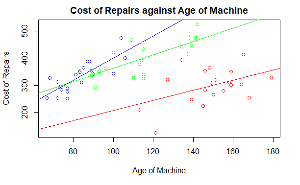

```r
abline(lm(lathe_cost ~ lathe_age), col= "red")
abline(lm(stamp_cost ~ stamp_age), col= "blue")
```

```
Propose a statistical model:
```

$$y\ =\ \beta_0\ +\ \beta_1x\ +\ \beta_2I_1\ +\ \beta_3I_2\ +\ \varepsilon$$

y = cost of repairs

x = age of machine

$I_1$ = welding machine = 1, else = 0.

$I_2$ = lathe = 1, else = 0.

if $I_1, I_2$ both = 0, then it’s a stamping machine

$\varepsilon$ = error variable

```r
cost <- data2$Repairs
age <- data2$Age
machine <- data2$Machine
n <- length(cost)
I1 <- data2$I1
I2 <- data2$I2
for(i in 1 : n)
{
  if(machine[i] == 1)
  {
    I1[i] = 1
    I2[i]= 0
  }
  else if(machine[i] == 2)
  {
    I1[i] = 0
    I2[i] = 1
  }
  else
  {
    I1[i] = 0
    I2[i] = 0
  }
}
Data.cost <- cbind(age, I1, I2)
linearModelVar <- lm(cost ~ Data.cost)
cat("# # # # The regression model # # # ","\n")
```

```
# # # # The regression model # # #
```

```r
print(summary(linearModelVar))
```

```
Call:
lm(formula = cost ~ Data.cost)

Residuals:
     Min       1Q   Median       3Q      Max
-103.125  -32.830   -2.634   27.351  133.348

Coefficients:
              Estimate Std. Error t value Pr(>|t|)
(Intercept)   119.2521    35.0004   3.407  0.00122 **
Data.costage    2.5382     0.4023   6.309 4.75e-08 ***
Data.costI1   -11.7553    19.7018  -0.597  0.55314
Data.costI2  -199.3737    30.7130  -6.492 2.39e-08 ***
---
Signif. codes:  0 ‘***’ 0.001 ‘**’ 0.01 ‘*’ 0.05 ‘.’ 0.1 ‘ ’ 1

Residual standard error: 48.59 on 56 degrees of freedom
Multiple R-squared:  0.5938,    Adjusted R-squared:  0.572
F-statistic: 27.29 on 3 and 56 DF,  p-value: 5.236e-11
```

```
From the printout, we can get the multiple regression model:
```

$$\hat{y} =\ b_0\ +\ b_1x\ +\ b_2I_1\ +\ b_3I_2\\
=\ 119.25\ +2.54x\ -11.76I_1\ -199.37I_2$$

### b

for $b_0$:

The intercept, b0, is 119.25.

One interpretation would be that when x, $I_1,I_2$ = 0, the cost of repairs is $119.25.

However, we have no data for age of machine is less than 0. So, this isn’t a correct assessment.

for $b_1$:

$b_1$ = 2.54. In this model, for each additional age of machine, the cost of repairs increases on the average by 2.54 (assuming the other variables are held constant).

for $b_2$:

$b_2$ = 11.76. A welding machine, on the average, cost for $11.76 less than a stamping machine.

for $b_3$:

$b_3$ = 199.37. A lathe, on the average, cost for $199.37 less than a stamping machine.

### c

Use t-test to test if welding machines cost less to repair than other machines.

Hypothesis testing about $\beta_2$ :

$$H_0:\beta_2\ =\ 0\\
H_1:\beta_2\ <\ 0$$

```r
linearModelVar <- lm(cost ~ Data.cost)
cat("# # # # The regression model # # # ","\n")
```

```
# # # # The regression model # # #
```

```r
print(summary(linearModelVar))
```

```
Call:
lm(formula = cost ~ Data.cost)

Residuals:
     Min       1Q   Median       3Q      Max
-103.125  -32.830   -2.634   27.351  133.348

Coefficients:
              Estimate Std. Error t value Pr(>|t|)
(Intercept)   119.2521    35.0004   3.407  0.00122 **
Data.costage    2.5382     0.4023   6.309 4.75e-08 ***
Data.costI1   -11.7553    19.7018  -0.597  0.55314
Data.costI2  -199.3737    30.7130  -6.492 2.39e-08 ***
---
Signif. codes:  0 ‘***’ 0.001 ‘**’ 0.01 ‘*’ 0.05 ‘.’ 0.1 ‘ ’ 1

Residual standard error: 48.59 on 56 degrees of freedom
Multiple R-squared:  0.5938,    Adjusted R-squared:  0.572
F-statistic: 27.29 on 3 and 56 DF,  p-value: 5.236e-11
```

Because we are doing left-tail test, p-value = 0.55314 / 2 = 0.27657

Since p-value for $I_1$ = 0.27657 > 0.05, we do not reject $H_0$.

There is no sufficient evidence to infer that welding machines cost less to repair than other machines.

## 18.39

### a

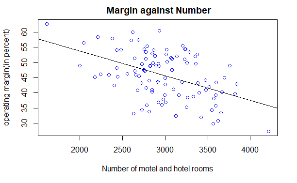

```r
#data processing
data3 <- read.csv("Xr17-17.csv",header = 1)
margin <- data3$Margin
number <- data3$Number
nearest <- data3$Nearest
office <- data3$Office.Space
enrollment <- data3$Enrollment
income <- data3$Income
distance <- data3$Distance
#Scatter diagram
plot(number,margin,col="blue",main = " Margin against Number",xlab="Number of motel and hotel rooms",ylab="operating margin(in percent)")
abline(lm(margin ~ number))
```

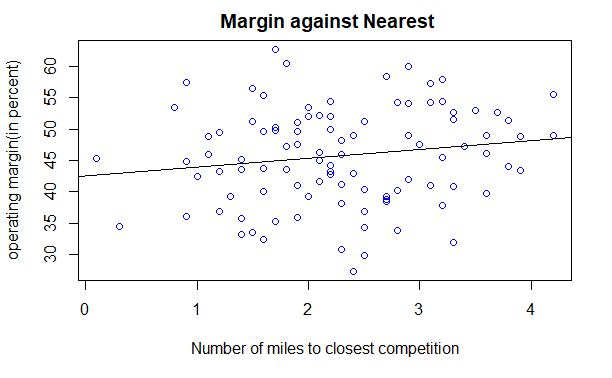

```r
plot(nearest,margin,col="blue",main = " Margin against Nearest",xlab="Number of miles to closest competition",ylab="operating margin(in percent)")
abline(lm(margin ~ nearest))
```

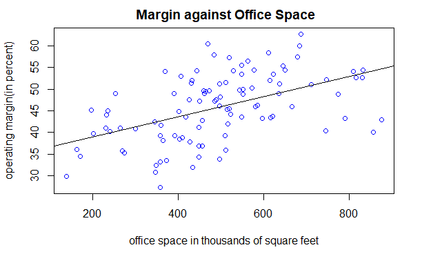

```r
plot(office,margin,col="blue",main = " Margin against Office Space",xlab="office space in thousands of square feet",ylab="operating margin(in percent)")
abline(lm(margin ~ office))
```

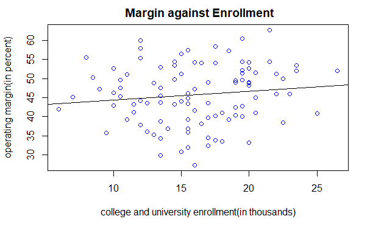

```r
plot(enrollment,margin,col="blue",main = " Margin against Enrollment",xlab="college and university enrollment(in thousands)",ylab="operating margin(in percent)")
abline(lm(margin ~ enrollment))
```

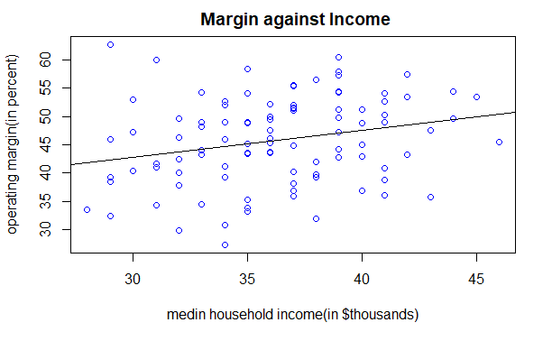

```r
plot(income,margin,col="blue",main = " Margin against Income",xlab="medin household income(in $thousands)",ylab="operating margin(in percent)")
abline(lm(margin ~ income))
```

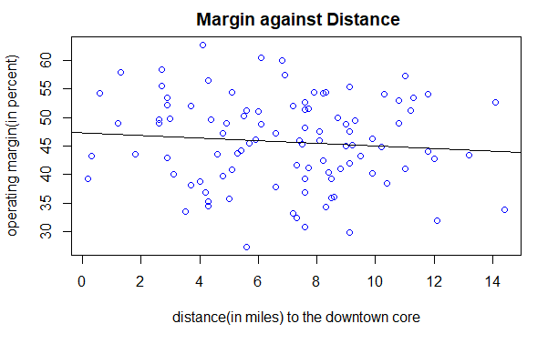

```r
plot(distance,margin,col="blue",main = " Margin against Distance",xlab="distance(in miles) to the downtown core",ylab="operating margin(in percent)")
abline(lm(margin ~ distance))
```

```r
#stepwise regression
library(olsrr)
n <- length(margin)
Data.Stepwise_MG <- data.frame(cbind(number, nearest,office,enrollment,income,distance))
linearModelVar <- lm(margin ~ number + nearest + office + enrollment + income + distance, data = Data.Stepwise_MG)
cat(" ","\n")
```

```r
Index_step <- ols_step_both_p(linearModelVar, details = TRUE)
```

```
Stepwise Selection Method
---------------------------

Candidate Terms:

1. number
2. nearest
3. office
4. enrollment
5. income
6. distance

We are selecting variables based on p value...


Stepwise Selection: Step 1

✔ office

                        Model Summary
--------------------------------------------------------------
R                       0.501       RMSE                6.741
R-Squared               0.251       Coef. Var          14.739
Adj. R-Squared          0.244       MSE                45.445
Pred R-Squared          0.220       MAE                 5.407
--------------------------------------------------------------
 RMSE: Root Mean Square Error
 MSE: Mean Square Error
 MAE: Mean Absolute Error

                               ANOVA
--------------------------------------------------------------------
                Sum of
               Squares        DF    Mean Square      F         Sig.
--------------------------------------------------------------------
Regression    1495.889         1       1495.889    32.917    0.0000
Residual      4453.569        98         45.445
Total         5949.458        99
--------------------------------------------------------------------

```

[output cut: 56 more lines]

```
--------------------------------------------------------------------
                Sum of
               Squares        DF    Mean Square      F         Sig.
--------------------------------------------------------------------
Regression    2572.130         2       1286.065    36.937    0.0000
Residual      3377.328        97         34.818
Total         5949.458        99
--------------------------------------------------------------------

                                  Parameter Estimates
----------------------------------------------------------------------------------------
      model      Beta    Std. Error    Std. Beta      t        Sig      lower     upper
----------------------------------------------------------------------------------------
(Intercept)    57.176         4.533                 12.613    0.000    48.179    66.173
     office     0.022         0.004        0.461     6.006
```

[output not shown]

```
    0.000     0.014     0.029
     number    -0.007         0.001       -0.427    -5.560    0.000    -0.010    -0.005
----------------------------------------------------------------------------------------



Stepwise Selection: Step 3

✔ income

                        Model Summary
--------------------------------------------------------------
R                       0.686       RMSE                5.728
R-Squared               0.471       Coef. Var          12.524
Adj. R-Squared          0.454       MSE                32.812
Pred R-Squared          0.429       MAE                 4.635
--------------------------------------------------------------
 RMSE: Root Mean Square Error
 MSE: Mean Square Error
 MAE: Mean Absolute Error

                               ANOVA
--------------------------------------------------------------------
                Sum of
               Squares        DF    Mean Square      F         Sig.
--------------------------------------------------------------------
Regression    2799.497         3        933.166     28.44    0.0000
Residual      3149.961        96         32.812
Total         5949.458        99
--------------------------------------------------------------------

                                  Parameter Estimates
----------------------------------------------------------------------------------------
      model      Beta    Std. Error    Std. Beta      t        Sig      lower     upper
----------------------------------------------------------------------------------------
(Intercept)    44.715         6.463                  6.918    0.000    31.886    57.545
     office     0.020         0.004        0.430     5.698    0.000     0.013     0.027
     number    -0.008         0.001       -0.437    -5.857    0.000    -0.010    -0.005
     income     0.379         0.144        0.198     2.632    0.010     0.093     0.664
----------------------------------------------------------------------------------------
```

[output cut: 126 more lines]

```
Regression    3009.184         4        752.296    24.307    0.0000
Residual      2940.274        95         30.950
Total         5949.458        99
--------------------------------------------------------------------

                                  Parameter Estimates
----------------------------------------------------------------------------------------
      model      Beta    Std. Error    Std. Beta      t        Sig      lower     upper
----------------------------------------------------------------------------------------
(Intercept)    41.273         6.415                  6.434    0.000    28.538    54.009
     office     0.020         0.003        0.419     5.702    0.000     0.013     0.026
     number    -0.008         0.001       -0.454    -6.238    0.000    -0.010    -0.005
     income     0.399         0.140        0.209     2.855    0.005     0.122     0.677
    nearest     1.654         0.635        0.189     2.603    0.011     0.392     2.915
----------------------------------------------------------------------------------------
```

```r
print(Index_step)
```

```
                             Stepwise Selection Summary
-------------------------------------------------------------------------------------
                     Added/                   Adj.
Step    Variable    Removed     R-Square    R-Square     C(p)        AIC        RMSE
-------------------------------------------------------------------------------------
   1     office     addition       0.251       0.244    50.5810    669.4168    6.7413
   2     number     addition       0.432       0.421    17.1580    643.7547    5.9007
   3     income     addition       0.471       0.454    11.6750    638.7852    5.7282
   4    nearest     addition       0.506       0.485     6.7730    633.8965    5.5633
-------------------------------------------------------------------------------------
```

```
From the printout, we can get the regression equation:
```

$$\hat{y}\ =\ 41.273\ +0.020*office\ -0.008*number\ +0.399*income\ +1.654*nearest$$

```r
n <- length(margin)
Data.margin <- cbind(number,nearest,office,income)
linearModelVar <- lm(margin ~ Data.margin)
cat("# # # # The regression model # # # ","\n")
```

```
# # # # The regression model # # #
```

```r
print(summary(linearModelVar))
```

```
Call:
lm(formula = margin ~ Data.margin)

Residuals:
     Min       1Q   Median       3Q      Max
-13.7135  -3.1234   0.0449   4.1846  14.5312

Coefficients:
                    Estimate Std. Error t value Pr(>|t|)
(Intercept)        41.273150   6.414992   6.434 5.01e-09 ***
Data.marginnumber  -0.007863   0.001260  -6.238 1.22e-08 ***
Data.marginnearest  1.653650   0.635316   2.603  0.01073 *
Data.marginoffice   0.019607   0.003439   5.702 1.33e-07 ***
Data.marginincome   0.399387   0.139886   2.855  0.00528 **
---
Signif. codes:  0 ‘***’ 0.001 ‘**’ 0.01 ‘*’ 0.05 ‘.’ 0.1 ‘ ’ 1

Residual standard error: 5.563 on 95 degrees of freedom
  (1 observation deleted due to missingness)
Multiple R-squared:  0.5058,    Adjusted R-squared:  0.485
F-statistic: 24.31 on 4 and 95 DF,  p-value: 7.23e-14
```

```r
ANOVA_T_lm <- anova(linearModelVar)
cat("# # # # The ANOVA Table # # # ","\n")
```

```
# # # # The ANOVA Table # # #
```

```r
print(ANOVA_T_lm)
```

```
Analysis of Variance Table

Response: margin
            Df Sum Sq Mean Sq F value   Pr(>F)
Data.margin  4 3009.2  752.30  24.307 7.23e-14 ***
Residuals   95 2940.3   30.95
---
Signif. codes:  0 ‘***’ 0.001 ‘**’ 0.01 ‘*’ 0.05 ‘.’ 0.1 ‘ ’ 1
```

### b

The output produced in exercise 17.17:

```r
n <- length(margin)
Data.margin <- cbind(number,nearest,office,enrollment,income,distance)
linearModelVar <- lm(margin ~ Data.margin)
cat("# # # # The regression model # # # ","\n")
```

```
# # # # The regression model # # #
```

```r
print(summary(linearModelVar))
```

```
Call:
lm(formula = margin ~ Data.margin)

Residuals:
    Min      1Q  Median      3Q     Max
-12.267  -3.022  -0.086   4.234  13.596

Coefficients:
                       Estimate Std. Error t value Pr(>|t|)
(Intercept)           38.138575   6.992948   5.454 4.04e-07 ***
Data.marginnumber     -0.007618   0.001255  -6.069 2.77e-08 ***
Data.marginnearest     1.646237   0.632837   2.601   0.0108 *
Data.marginoffice      0.019766   0.003410   5.796 9.24e-08 ***
Data.marginenrollment  0.211783   0.133428   1.587   0.1159
Data.marginincome      0.413122   0.139552   2.960   0.0039 **
Data.margindistance   -0.225258   0.178709  -1.260   0.2107
---
Signif. codes:  0 ‘***’ 0.001 ‘**’ 0.01 ‘*’ 0.05 ‘.’ 0.1 ‘ ’ 1

Residual standard error: 5.512 on 93 degrees of freedom
  (1 observation deleted due to missingness)
Multiple R-squared:  0.5251,    Adjusted R-squared:  0.4944
F-statistic: 17.14 on 6 and 93 DF,  p-value: 3.034e-13
```

```r
ANOVA_T_lm <- anova(linearModelVar)
cat("# # # # The ANOVA Table # # # ","\n")
```

```
# # # # The ANOVA Table # # #
```

```r
print(ANOVA_T_lm)
```

```
Analysis of Variance Table

Response: margin
            Df Sum Sq Mean Sq F value    Pr(>F)
Data.margin  6 3123.8  520.64  17.136 3.034e-13 ***
Residuals   93 2825.6   30.38
---
Signif. codes:  0 ‘***’ 0.001 ‘**’ 0.01 ‘*’ 0.05 ‘.’ 0.1 ‘ ’ 1
```

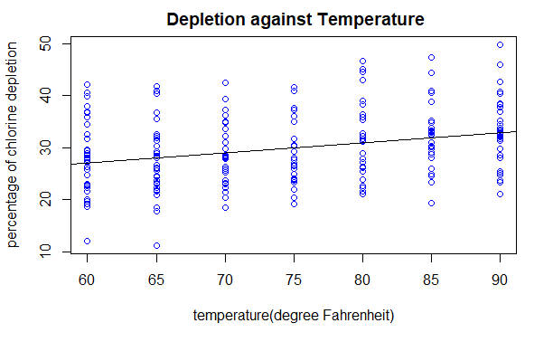

```r
#data processing
data4 <- read.csv("Xr18-49.csv",header = 1)
depletion <- data4$Pct.Dep
temp <- data4$Temperature
ph <- data4$PH.Level
weather <- data4$Weather
#Scatter diagram
plot(temp,depletion,col="blue",main = " Depletion against Temperature",xlab="temperature(degree Fahrenheit)",ylab="percentage of chlorine depletion")
abline(lm(depletion ~ temp))
```

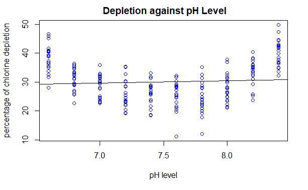

```r
plot(ph,depletion,col="blue",main = " Depletion against pH Level",xlab="pH level",ylab="percentage of chlorine depletion")
abline(lm(depletion ~ ph))
```

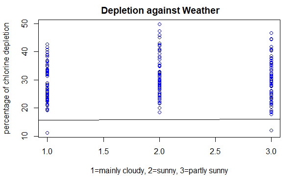

```r
plot(weather,depletion,col="blue",main = " Depletion against Weather",xlab="1=mainly cloudy, 2=sunny, 3=partly sunny",ylab="percentage of chlorine depletion")
abline(lm(depletion ~ temp))
```

1. Since it is believed that pH levels around 7.5 use the least chlorine, we use a variable to represent the diffrence between pH level of the water and 7.5.
2. We use 2 indicator variables to represent the weather variable.

The equation:

$$y\ =\ \beta_0\ +\beta_1x_1\ +\beta_2x_2\ +\beta_3I_1\ +\beta_4I_2\ +\varepsilon$$
y = percentage of chlorine depletion over 8 hours

$x_1$ = temperature(degree Fahrenheit)

$x_2$ = |pH level - 7.5|

$I_1$ = 1 if it is mainly cloudy, otherwise 0

$I_2$ = 1 if it is sunny, otherwise 0

if $I_1$ = $I_2$ = 0, then it is partly sunny

$\varepsilon$ = error variable

### b

```r
#adjustment
n <- length(depletion)
I1 <- data4$I1
I2 <- data4$I2
ph_adj <- vector("double", length = n)
for(i in 1:n)
{
  ph_adj[i] = abs(ph[i] - 7.5)
  if(weather[i] == 1)
  {
    I1[i] = 1
    I2[i] = 0
  }
  else if(weather[i] == 2)
  {
    I1[i] = 0
    I2[i] = 1
  }
  else
  {
    I1[i] = 0
    I2[i] = 0
  }
}

#regression model
Data.Depletion <- cbind(temp, ph_adj, I1,I2)
linearModelVar <- lm(depletion ~ Data.Depletion)
cat("# # # # The regression model # # # ","\n")
print(summary(linearModelVar))
```

[output not shown]

$$\hat{y}\ =\ 6.84\ +0.19x_1\ +17.18x_2\ -1.07I_1\ +1.16I_2$$

### c

We use the F-test of ANOVA to test the validity of the model. Hypothesis:

$$H_0: \beta_1\ =\ \beta_2\ =\ \beta_3\ =\ \beta_4\ =\ 0\\
H_1: At\ least\ one\ \beta_i\ is\ not\ equal\ to\ 0.$$

```r
linearModelVar <- lm(depletion ~ Data.Depletion)
ANOVA_T_lm <- anova(linearModelVar)
cat("# # # # The ANOVA Table # # # ","\n")
print(ANOVA_T_lm)
```

[output not shown]

Conclusion:

Since p value < 2.2e-16 << 0.05, we reject $H_0$.

There is sufficient evidence to say that at least one of the $b_i$ is not equal to zero.

Thus, at least one independent variable is related to y. This regression model is valid.

### d, e, f

Use t-test to test (d), (e), (f)

```r
linearModelVar <- lm(depletion ~ Data.Depletion)
cat("# # # # The regression model # # # ","\n")
print(summary(linearModelVar))
```

[output not shown]

### d

Hypothesis testing about $\beta_1$ :

$$H_0:\beta_1\ =\ 0\\
H_1:\beta_1\ >\ 0$$
for $\beta_1$ :

Because we are doing right-tail test, p-value = 2.66e-09 / 2 = 1.33e-09

Since p-value = 1.33e-09 < 0.05, we reject $H_0$.

There is sufficient evidence to infer that higher temperatures deplete chlorine more quickly.

### e

Hypothesis testing about $\beta_2$ :

$$H_0:\beta_2\ =\ 0\\
H_1:\beta_2\ \neq\ 0$$
for $\beta_2$ :

Since p-value = < 2e-16 << 0.05, we reject $H_0$.

There is sufficient evidence to infer that the belief about the relationship between chlorine depletion and pH level is correct.

### f

Hypothesis testing about $\beta_3$ :

$$H_0:\beta_3\ =\ 0\\
H_1:\beta_3\ \neq\ 0$$

for $\beta_3$ :

There is NO sufficient evidence to infer that on mainly cloudy days, the depletion of chlorine will be lower.

Hypothesis testing about $\beta_4$ :

$$H_0:\beta_4\ =\ 0\\
H_1:\beta_4\ \neq\ 0$$

for $\beta_4$ :

There is NO sufficient evidence to infer that on sunny days, the depletion of chlorine will be higher.

```
Conclusion:
```

We can not infer that weather is a factor in chlorine depletion.